# Задача математического программирования

Задачей **условной оптимизации** (**математического программирования**) называется задача вида:

найти $$ \min f(x) $$ при условиях $$ \left\{ \begin{array}{ll} g_i (x) \ge 0 & (i=1,2,\dots,m),\\ h_k (x) = 0 & (k=1,2,\dots,p),\\ x \in S \subseteq {\bf R}^n \end{array} \right. $$

Для решения такого сорта задач можно использовать `scipy.optimize.minimize`.

Важный класс таких задач образуют задачи **линейной оптимизации** (**линейного программирования**) - в них целевая функция и левые части ограничений являются линейными:

найти $$ \min c^{\top}x $$ при условиях $$ \left\{ \begin{array}{l} A'x \ge b' ,\\ A''x = b'' ,\\ l \le x \le u, \end{array} \right. $$ где $x\in {\bf R}^n$, $A'\in {\bf R}^{m\times n}$, $A''\in {\bf R}^{p\times n}$, $b'\in {\bf R}^m$, $b''\in {\bf R}^p$, $l\in {\bf R}^n$, $u\in {\bf R}^n$ и некоторые компоненты векторов $l$, $u$ могут быть равны $-\infty$, $+\infty$ соответственно.

Многие задачи комбинаторной оптимизации могут быть сформулированы в виде задач (**смешанного**) **целочисленного** **линейного программирования**:

найти $$ \min c^{\top}x $$ при условиях $$ \left\{ \begin{array}{ll} A'x \ge b' ,\\ A''x = b'' ,\\ l \le x \le u, \\ x_j \in {\bf Z}^n & (j \in J). \end{array} \right. $$

Один из вариантов вызова функции `scipy.optimize.linprog`:

```
scipy.optimize.linprog(c, A_ub, b_ub, A_eq, b_eq, bounds=None)
```

где `A_ub`, `b_ub`, `A_eq`, `b_eq` содержат соответственно $A'$, $b'$, $A''$, $b''$, а `bounds` содержит нижние и верхние границы для $x_j$. По умолчанию нижняя граница для всех $x_j$ равна $0$, а верхняя равна $+\infty$.

**Пример 1.**

```python
from scipy.optimize import linprog
import numpy as np
```

```python
c = [-1, -2, -3]
A = [[1, 3, 4], [2, 3, 1]]
b = [1, 2]
linprog(c, A_ub=A, b_ub=b)
```

```
     con: array([], dtype=float64)
     fun: -1.0000000017885735
 message: 'Optimization terminated successfully.'
     nit: 4
   slack: array([-2.89089552e-09, -3.88846733e-10])
  status: 0
 success: True
       x: array([9.99999999e-01, 5.80827131e-10, 5.21494658e-10])
```

**Пример 2.**

Фирма производит столы и стулья. Объемы ресурсов, требуемых для производства одного стула и одного стола, а также имеющиеся запасы ресурсов и цены на товар приведены в следующей таблице:

| Ресурсы | Стул | Стол | Запасы |
| --- | --- | --- | --- |
| Древесина (кг) | 5 | 15 | 270 |
| Кожа (м${}^2)$ | 0.5 |  | 15 |
| Клей (г) | 120 | 200 | 6000 |
| Трудовые ресурсы (чел$\cdot$ч) | 10 | 15 | 360 |
| *Цена* (руб.) | 1000 | 2000 |  |

Необходимо определить оптимальный план производства стульев и столов, максимизирующий прибыль.

Составляем математическую модель данной задачи. Обозначим $x_1$ количество производимых стульев, а $x_2$ --- количество столов.

Необходимо максимизировать прибыль: $$ \max(1000 x_1 + 2000 x_2) $$ при ограничениях $$ \left\{ \begin{array}{rcrcrr} 5x_1 & + & 15x_2 & \le & 270, \\ 0.5x_1 & & & \le & 15, \\ 120x_1 & + & 200x_2 & \le & 6000, \\ 10x_1 & + & 15x_2 & \le & 360, \\ x_1 & & & \ge & 0, \\ & & x_2 & \ge & 0. \end{array} \right. $$

Строго говоря, данная задача является задачей *целочисленного* линейного программирования, так как $x_1$, $x_2$ должны быть целыми. Для начала забудем про эти требования.

Умножая (или деля) каждое неравенство на подходящий множитель и заменяя целевую функцию $1000 x_1 + 2000 x_2$ на $x_1 + 2x_2$ (теперь прибыль будет измеряться не в рублях, а в тыс. рублей), получаем следующую ЗЛП: $$ \max(x_1 + 2x_2) $$ при ограничениях $$ \left\{ \begin{array}{rcrcrr} x_1 & + & 3x_2 & \le & 54, \\ x_1 & & & \le & 30, \\ 3x_1 & + & 5x_2 & \le & 150, \\ 2x_1 & + & 3x_2 & \le & 72, \\ x_1 & & & \ge & 0, \\ & & x_2 & \ge & 0. \end{array} \right. $$

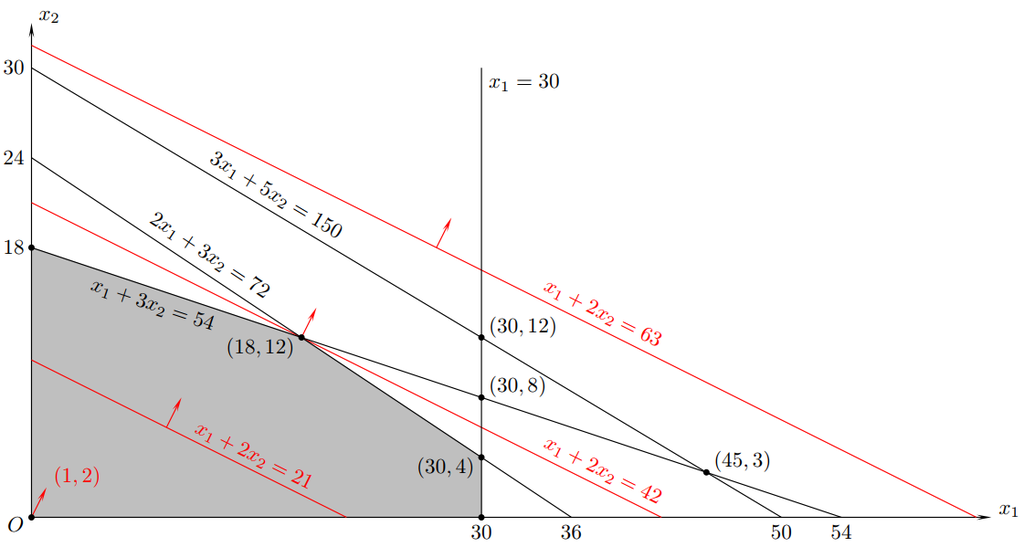

```python
c = [-1000, -2000]
A = [[5, 15], [.5, 0], [120, 200], [10, 15]]
b = [270, 15, 6000, 360]
```

```python
# Можно и не делать
c = np.array(c)
A = np.array(A)
b = np.array(b)
```

```python
linprog(c, A_ub=A, b_ub=b)
```

```
     con: array([], dtype=float64)
     fun: -41999.99999921981
 message: 'Optimization terminated successfully.'
     nit: 8
   slack: array([5.02336661e-09, 6.00000000e+00, 1.44000000e+03, 6.67944278e-09])
  status: 0
 success: True
       x: array([18., 12.])
```

```python
c = [-1, -2]
A = [[1, 3], [1, 0], [3, 5], [2, 3]]
b = [54, 30, 150, 72]
```

```python
linprog(c, A_ub=A, b_ub=b)
```

```
     con: array([], dtype=float64)
     fun: -41.99999974797202
 message: 'Optimization terminated successfully.'
     nit: 5
   slack: array([1.71260353e-07, 1.20000004e+01, 3.60000008e+01, 5.84823596e-07])
  status: 0
 success: True
       x: array([17.99999959, 12.00000008])
```

Поменяем немного условия:

```python
b = [53, 25, 150, 71]

linprog(c, A_ub=A, b_ub=b)
```

```
     con: array([], dtype=float64)
     fun: -41.33333318613988
 message: 'Optimization terminated successfully.'
     nit: 5
   slack: array([1.08664715e-07, 7.00000022e+00, 3.76666671e+01, 3.32915647e-07])
  status: 0
 success: True
       x: array([17.99999978, 11.66666671])
```

Решение получилось дробным, хотя по смыслу оно должно быть целочисленным